# 01 Homework

#1 (2018-09-24)

VisStat HT18 #1

## Homework

- Read Wilson et al. 2017. *Good Enough Practices in Scientific Computing.* PLOS Computational Biology 13 (6): e1005510. https://doi.org/10.1371/journal.pcbi.1005510 and prepare a question or comment for next meeting
- Follow the instructions in the slides following to:
  1. Install the `tidyverse` library
  2. Experiment with writing ‘functions’ to package together a bunch of commands into a meaningful action
- Work through notes from class. These are posted as `01.introduction-notes.Rmd`. Please experiment! Email me any questions and I will address them in the next meeting.

## Tidyverse

- The [tidyverse](https://www.tidyverse.org/) is a large collection of packages (called ‘libraries’ in R speak) that impose a consistent design philosophy on R
- For people who have learned ‘old-fashioned’ R this counts as advanced
- But for complete beginners it can offer a better entry point to the language
  - no need to deal with the legacy of messy, illogical design choices* that have been made over the years
- To activate a library enter the following (you will need to do this once each session and at the start of each script)

```r
library(tidyverse)
```

* not actually choices in many cases

## Install a package

- Install the `tidyverse` package (**Warning:** takes a long time!)
- Go to “Tool” → “Install packages…” menu item

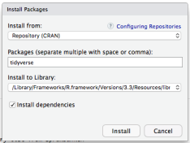

- Leave the “Install from” field at the default
- Make sure “Install dependencies” is checked
- The default “Install to library” setting on my computer makes a *global* install (all users); on the lab computer it makes a *local* install (only for you). If you have problems installing packages we might need to fix this.

## A note on R ‘names’

- Functions, variables etc are the nouns and verbs of the R language.
- Legal R names:
  - a sequence of letters digits, the period and underscores; and **not** a reserved word
  - **otherwise** must be in `backticks`

i.e. backticks are used to refer to names that are otherwise reserved or illegal

This is important for column names in tables, since they often have e.g. spaces in them

## What’s a function?

```r
sqrt(4) # square root
```

```
## [1] 2
```

```r
sqrt(19)
```

```
## [1] 4.359
```

- The `[1]` just appears in the console — just ignore it
- R has lots of *built-in functions*
- You can define your own functions with:

```r
# This isn't a real function, so it won't work
FUNCTION_NAME <- function(ARGUMENTS) {ACTIONS TO CARRY OUT ON ARGS}
```

## The grammar of functions

```r
# This isn't a real function, so it won't work
want <- function(subject, object){
  subject "WANTS" object
}
want(👱, 🍰)
```

```
R> Michael wants cake
```

```r
sit <- function(subject, destination=NA){
  subject "SITS" (IN destination)
  }
sit(🐨)
sit(🐨, 🌳)
```

```
R> The koala is sitting
R> The koala is sitting in the tree
```

## Make a function

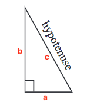

a² + b² = c²

```r
get.hypotenuse <- function(a, b){
  a2 <- a ** 2
  b2 <- b ** 2
  c2 = a2 + b2
  c <- sqrt(c2) # square root
  c # this is the value that will be "returned"
}
get.hypotenuse(3, 4)
```

```
## [1] 5
```

## Markdown notebooks

- “File” → “New File” → New Notebook"
- Exercises:
  - Redo the hypotenuse example in a notebook (play around, e.g. try defining the function in one line)
  - Can you think of other formulae that you could turn into a function (e.g. the area of a circle is πr²; volume of a sphere is 4/3πr³; hint: in R pi is `pi`)

## Help function

- `help()` is a function that returns information about other functions. Here’s how to get help for the `read_delim` family of functions:

```r
help(read_delim)
```

- You would get the same output for e.g. `help(read_csv2)`, `help(read_delim)` etc.
- The `read_delim` functions return a `tibble`, a special format of tabular data like a table from a spreadsheet
- Help on `tidyverse` functions is only available if `tidyverse` is loaded